# Incarceration Trends Analysis

Lauryn Ewing

2022-11-01

[figure not shown]

[figure not shown]

## Abstract

This report goes over the Vera Institute incarceration trends data set, in which patterns of inequality and racial disparities are revealed. This is done by the examination of certain data values and variables calculated using code and analytical methods.

## Introduction

The data set, Incarceration Trends, by Vera Institute presents incarceration data from the US. The total jail population is a hundredth of the actual population. Looking further into this data, the numbers for total jail population are very high. Mass incarceration is a huge problem in the United States, it is considered an epidemic. The state with the highest jail population is California. From the data set, the maximum Black jail population is 13143.92 (unit: 0.01). While the maximum white jail population value was. 7036.59 (unit: 0.01). There is a significant difference between these two values. Black people are disproportionally incarcerated compared to their counterparts.

Beyond the data, within these prisons, there are racial disparities. Data Feminism mentions that BIPOC are less likely to get a mental health diagnosis. The other option to this is punishment.

By examining this data, I hope to seek further information about incarceration and find patterns that show such disparities, racism, and inequality of the prison system.

## Data Summary

```
## [1] "CA"
```

```
## [1] "CA"
```

```
## [1] 13143.92
```

```
## [1] 7036.59
```

I wrote three questions that I answered to find values that show patterns of inequality. The first being, “What are the states that have the maximum value of Black and White population in jail?” Both of the states were California.

The second question was, “What is the maximum value of Black population in jail?” The unit of black_jail_pop is 0.01. The maximum value was 13143.92. I wanted to be able to compare this value to the maximum value of White population in jail, in order to see the disparities.

The last question about the maximum value of White population in jail resulted in a value of 7036.59. We can clearly see the major difference of the two values.

## Section 3: Growth of the US Prison Population

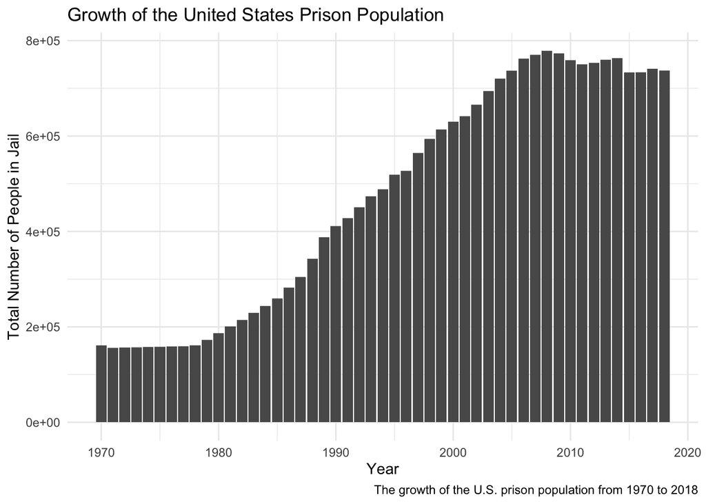

```r
plot_jail_pop_for_us()
```

This chart demonstrates the growth of the United States prison population from the year 1970 to 2018. At the first few years, there is a decade-long plateau of the number of people incarcerated. But as the years pass, there is a clear and drastic incline as the years pass. This raises the question, what caused such a significant increase in incarceration numbers?

## Section 4: Growth of Prison Population by State

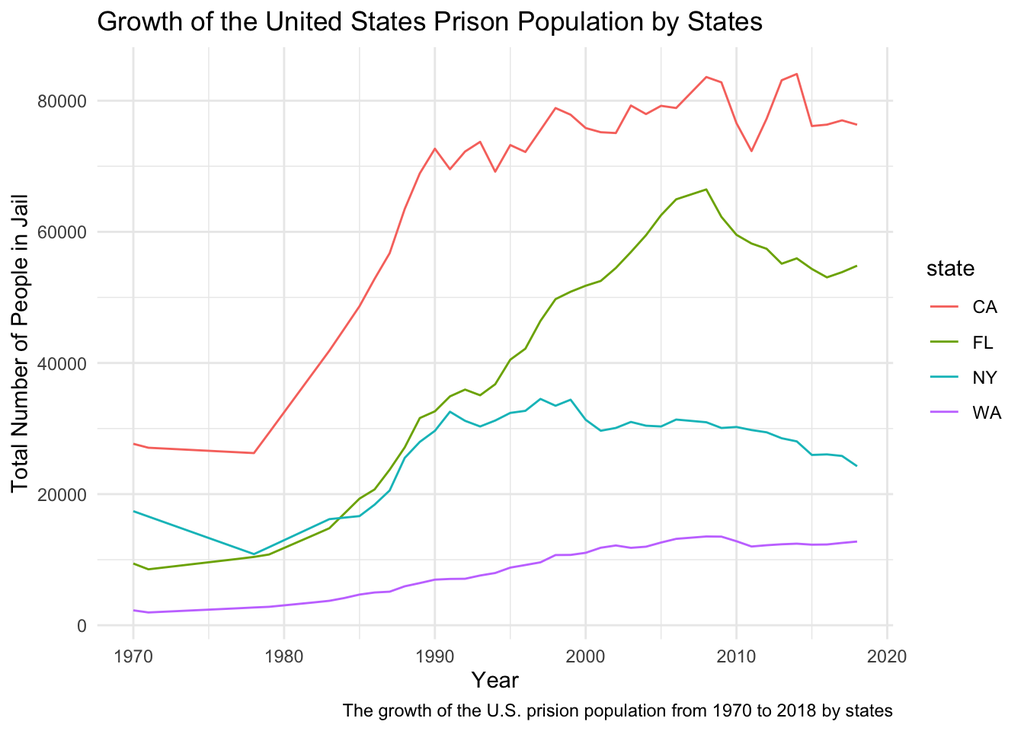

```r
plot_jail_pop_for_states(c("WA", "CA", "FL", "NY"))
```

This chart is a visualization of the growth of the United States prison population. The chart is specifically the states of California, Florida, New York, and Washington. Washington appears to be relatively low compared to its counterparts. California has a dramatic lead in terms of number of people in jail. California had a plateau for around a decade and suddenly started to incline, similar to the first US chart. Each state had some sort of incline starting at the 80’s, indicating in potentially a law change or change in the system. A question that lingers is why is Washington significantly lower than the other states? Does it have to do with the state’s own laws?

## Section 5

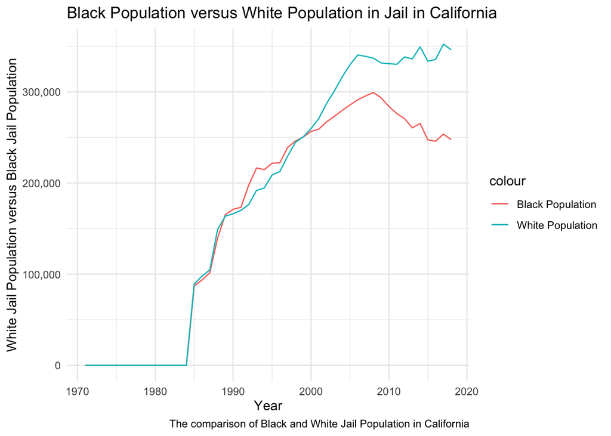

# Section 6

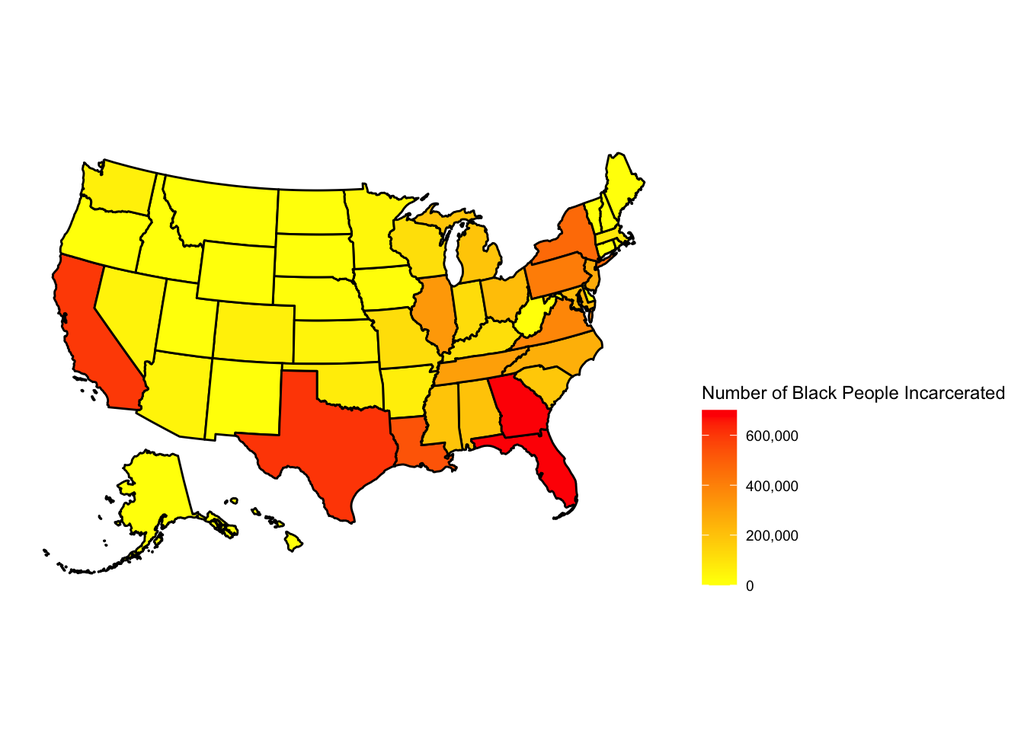

This is a data visualization of the number of black people incarcerated in the United States. Looking at the key, the states colored red on the map are the states with higher numbers of black jail population. These states include: California, Texas, Florida, and Georgia. Why are these states significantly higher than the rest for black jail population? Again, alluding to potential law differences and unjust prison systems.